# Collaborative Practice - Comparing Amounts

Names Here Please

2024-09-16

```r
library(tidyverse)
gapminder <- read_csv("gapminder.csv")
```

```
## ──────────────────────────────────────────────────────── Delimiter: "," chr
## (2): country, continent dbl (5): ...1, year, lifeExp, pop, gdpPercap
```

### 1. Filter the dataset

Filter the data set to include only observations from the year 2007. Assign this subset to a new object called `gapminder_2007`.

```r
gapminder_2007 <- gapminder %>%
  filter(year == 2007)
```

### 2. Compare life expectancy across continents

Using `gapminder_2007`, calculate the average life expectancy for each continent. Then, create a dot plot to display these averages, with one point per continent. Use `labs()` to give your plot a title and label the axes. Reorder the dots/continents from lowest to highest life expectancy.

Hints: - First, use `group_by()` and `summarize()` to calculate the averages. - Use `geom_point()` to create the dot plot. - Remember to `ungroup()` after summarizing to avoid issues with subsequent operations. - `fct_reorder()` from the `forcats` package can be used to reorder the continents based on the average life expectancy.

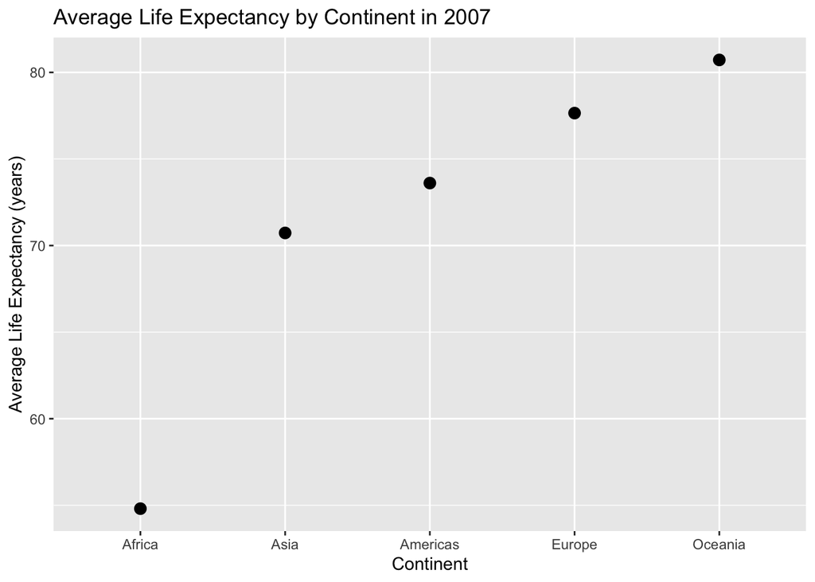

```r
gapminder_2007 %>%
  group_by(continent) %>%
  summarize(mean_lifeExp = mean(lifeExp)) %>%
  ungroup() %>%
  mutate(continent = fct_reorder(continent, mean_lifeExp)) |>
  ggplot(aes(x = continent, y = mean_lifeExp)) +
  geom_point(size = 3) +
  labs(title="Average Life Expectancy by Continent in 2007", x="Continent", y="Average Life Expectancy (years)")
```

### 3. Highlight countries with the lowest and highest GDP per capita

First, categorize countries into “High GDP” or “Low GDP” groups based on the median GDP per capita for 2007.

Hint: - Use `mutate()` and `case_when()` to create a new variable called `gdp_category` that labels countries as “High GDP” if their GDP per capita is above the median, and “Low GDP” otherwise.

```r
gapminder_2007 <- gapminder_2007 %>%
  mutate(gdp_category = case_when(
    gdpPercap > median(gdpPercap, na.rm = TRUE) ~ "High GDP",
    TRUE ~ "Low GDP"
  ))
```

### 4. Create a dot plot to compare GDP categories

Using the `gapminder_2007` dataset with your new `gdp_category` variable, create a dot plot that shows the average life expectancy for countries in the “High GDP” and “Low GDP” categories. Note that the plot should have one point per gdp category (i.e., two points total). Please use `coord_flip()` to flip the plot, placing categories on the left-hand side.

Hint: - Group by `gdp_category` and calculate the average life expectancy for each group. - Ungroup after summarizing to avoid issues with subsequent operations.

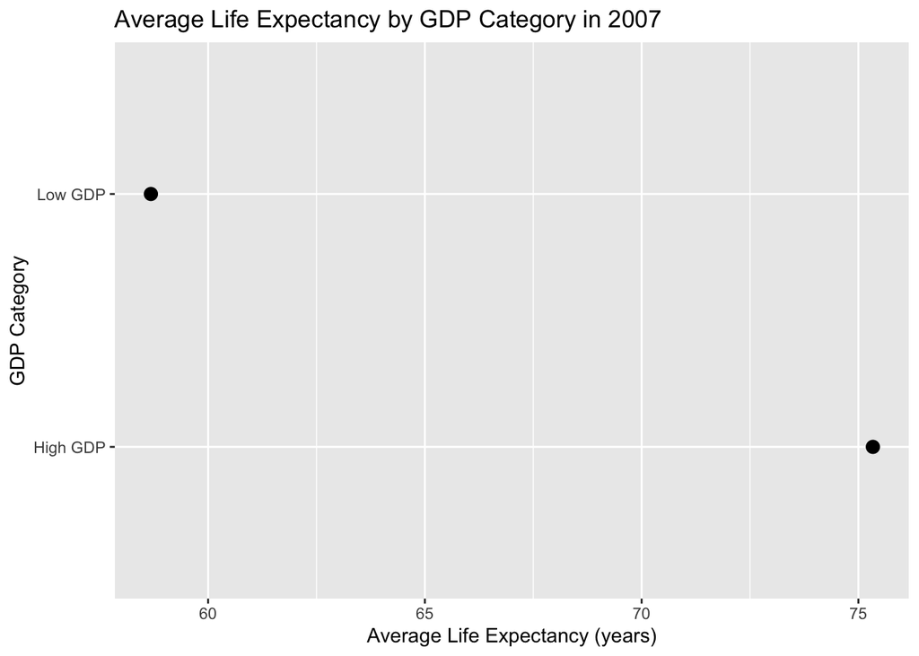

```r
gapminder_2007 %>%
  group_by(gdp_category) %>%
  summarize(mean_lifeExp = mean(lifeExp, na.rm=T)) %>%
  ungroup() %>%
  ggplot(aes(x = gdp_category, y = mean_lifeExp)) +
  geom_point(size = 3) +
  coord_flip() +
  labs(title="Average Life Expectancy by GDP Category in 2007", x="GDP Category", y="Average Life Expectancy (years)")
```

### 5. Compare GDP across continents using faceting or dodging

Using the full `gapminder` dataset, create a bar plot (`geom_col()`) comparing the average GDP per capita across continents for each year. Use either faceting or dodging to compare the GDPs side by side for each year.

Hints: - Group by `continent` and `year` to calculate the average GDP per capita. - Experiment with faceting and dodging to see which you like better.

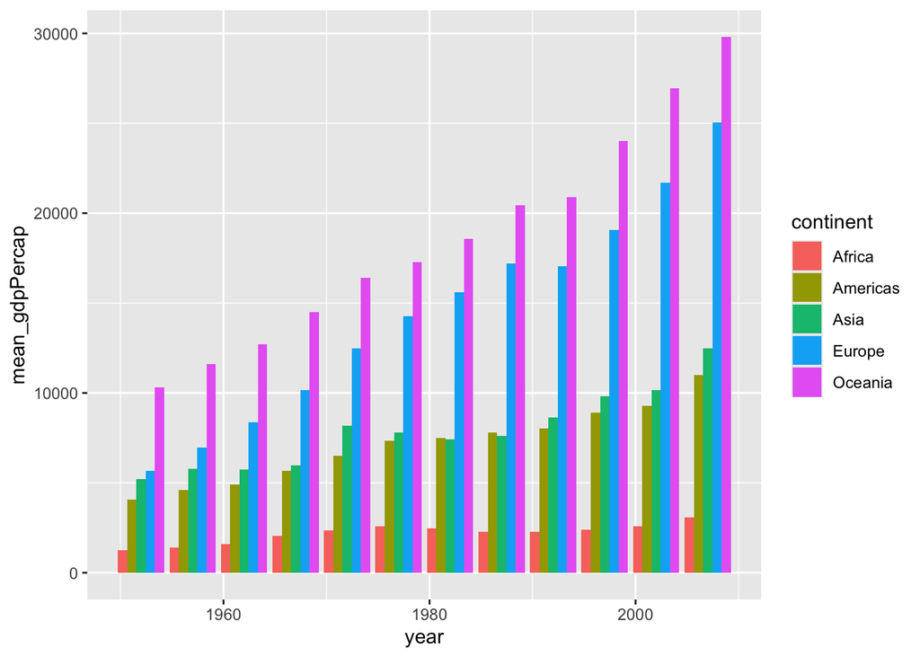

```r
#Dodging
gapminder %>%
  group_by(continent, year) %>%
  summarize(mean_gdpPercap = mean(gdpPercap)) %>%
  ggplot(aes(x = year, y = mean_gdpPercap, fill = continent)) +
  geom_col(position = "dodge")
```

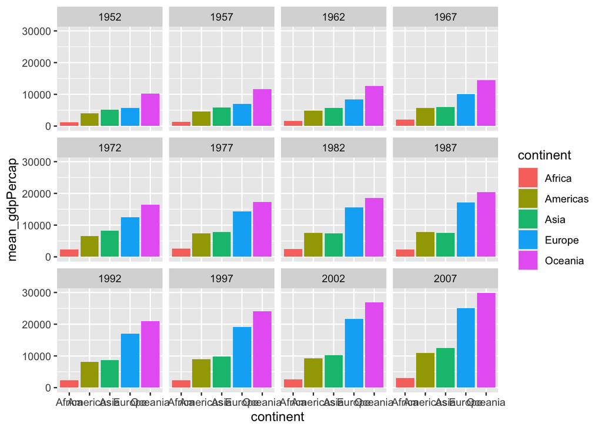

```r
#Faceting
gapminder %>%
  group_by(continent, year) %>%
  summarize(mean_gdpPercap = mean(gdpPercap)) %>%
  ggplot(aes(x = continent, y = mean_gdpPercap, fill = continent)) +
  geom_col() +
  facet_wrap(~ year)
```

### 6. Heatmap of population by country and year

Choose only ONE continent. Create a heatmap using geom_tile() to show the population of each country over time. The x-axis should represent years, the y-axis should represent countries, and the fill should represent population size.

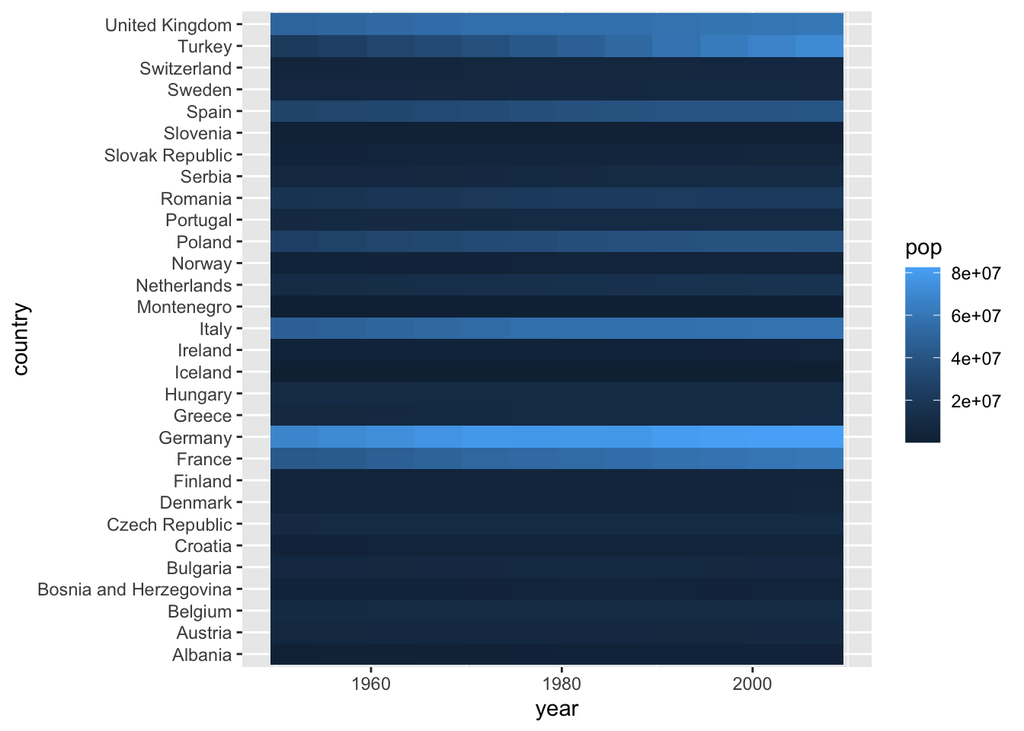

```r
gapminder %>%
  filter(continent == "Europe") %>%
  ggplot(aes(x = year, y = country, fill = pop)) +
  geom_tile()
```

### 7. Save your heatmap

Use `ggsave() to save your heatmap from exercise 6 as a .png file.

```r
ggsave("population_heatmap.png",width = 10, height = 6, dpi = 96)
```